# DV_RProject2

Zareen Khayrattee, Kayne Khoury, Juanito Taveras

October 1, 2015

# Extraction, Transformation, Loading

To fix our data so it can be loaded into Oracle correctly, we first replaced the periods in our column rows with underscores.

> names(df) <-gsub(“\.+”, “_“, names(df))

We then, set our measures appropriately:

> measures <- c(“Year”, “Deaths_less_than_1_month”, “Deaths_1_to_59_months”, “Deaths_0_to_4_years”)

We created our re-formatted csv, then created our SQL concatenation

And pasted it into SQL developer. We ran this script, then imported our reformatted CSV to create the table.

# Plot 1

The very interesting thing about this workflow is that there are no cumulative distribution of less than .10, or even less than .90 for that matter, meaning that no matter what country you are in, fatalities from respiratory infections in babies less than one month old is a huge problem. However, the risk of death from respiratory infections does decrease as the child gets older for people in most countries, with the very apparent exception of India, where it’s still a huge problem in children up to almost 5 years of age. Deaths of children ages 0-1 month from respiratory infections is plotted on the X-axis, and Total Deaths of children ages 1-59 months is plotted on the Y-axis.

```r
source("../02 Data Wrangling/Data_Wrangling_P2.R",echo=TRUE)
```

```
##
## > require("jsonlite")
```

```
##
## > require("RCurl")
```

```
##
## > require("dplyr")
```

```
##
## > require("tidyr")
```

```
##
## > require("ggplot2")
```

```
##
## > require("extrafont")
```

```
## Registering fonts with R
```

```
##
## > df <- data.frame(fromJSON(getURL(URLencode("129.152.144.84:5001/rest/native/?query=\"select * from infected\""),
## +     httpheader = c(DB = "jdbc:or ..." ... [TRUNCATED]
##
## > df %>% mutate(Percent_deaths_less_than_one_month = cume_dist(DEATHS_LESS_THAN_1_MONTH)) %>%
## +     filter(Percent_deaths_less_than_one_month <= 0.1  .... [TRUNCATED]
```

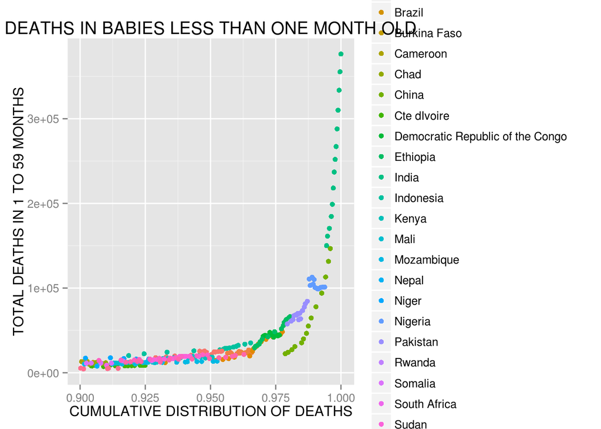

```
##
## > df %>% mutate(TOTAL_DEATHS = DEATHS_LESS_THAN_1_MONTH +
## +     DEATHS_1_TO_59_MONTHS + DEATHS_0_TO_4_YEARS) %>% arrange(desc(TOTAL_DEATHS)) %>%
## +   .... [TRUNCATED]
## Source: local data frame [2,716 x 6]
## Groups: YEAR
##
##    COUNTRY YEAR DEATHS_LESS_THAN_1_MONTH DEATHS_1_TO_59_MONTHS
## 1    India 2000                    64343                376482
## 2    India 2001                    60894                355439
## 3    India 2002                    57566                333685
## 4    India 2003                    54752                310094
## 5    India 2004                    51374                287994
## 6    India 2005                    48192                267185
## 7    India 2006                    45070                252001
## 8    India 2007                    39919                237060
## 9    India 2008                    36675                218156
## 10   India 2009                    33802                198998
## ..     ...  ...                      ...                   ...
## Variables not shown: DEATHS_0_TO_4_YEARS (int), TOTAL_DEATHS (int)
```

# Plot 2

The workflow shows the top ten mortality percentages of children less than one month old for countries with a total number of deaths greater than 100,000. The data first creates a secondary data frame that counts the total deaths for every country for all years. The data is then filtered only to consider countries with more than 100,000 total deaths. Another column is added to calculate the percentage of children that were less than one month old. The table is then arranged in descending order and plotted. Interestingly, amongst the countries with more than 100,000 deaths, the highest percentages less than one month old were either in Africa or Asia.

```r
source("../02 Data Wrangling/Data_Wrangling_P3.R",echo=TRUE)
```

```
##
## > require("jsonlite")
##
## > require("RCurl")
##
## > require("dplyr")
##
## > require("tidyr")
##
## > require("ggplot2")
##
## > require("extrafont")
##
## > df <- data.frame(fromJSON(getURL(URLencode("129.152.144.84:5001/rest/native/?query=\"select * from infected\""),
## +     httpheader = c(DB = "jdbc:or ..." ... [TRUNCATED]
##
## > pcnt <- df %>% group_by(COUNTRY) %>% summarise(total = sum(DEATHS_0_TO_4_YEARS),
## +     less_1_month = sum(DEATHS_LESS_THAN_1_MONTH)) %>% filter(tot .... [TRUNCATED]
##
## > mutate(pcnt, percent_less_1_month = (less_1_month/total) *
## +     100) %>% arrange(desc(percent_less_1_month)) %>% select(COUNTRY,
## +     percent_le .... [TRUNCATED]
## Source: local data frame [10 x 2]
##
##         COUNTRY percent_less_1_month
## 1         China             21.23522
## 2   Cte dIvoire             18.30187
## 3         Ghana             18.00081
## 4       Nigeria             16.79913
## 5    Mozambique             16.18148
## 6  South Africa             15.68039
## 7    Bangladesh             15.20965
## 8      Pakistan             15.10481
## 9         India             14.79581
## 10       Zambia             14.46344
##
## > mutate(pcnt, percent_less_1_month = (less_1_month/total) *
## +     100) %>% arrange(desc(percent_less_1_month)) %>% head(10) %>%
## +     ggplot(aes(x  .... [TRUNCATED]
```

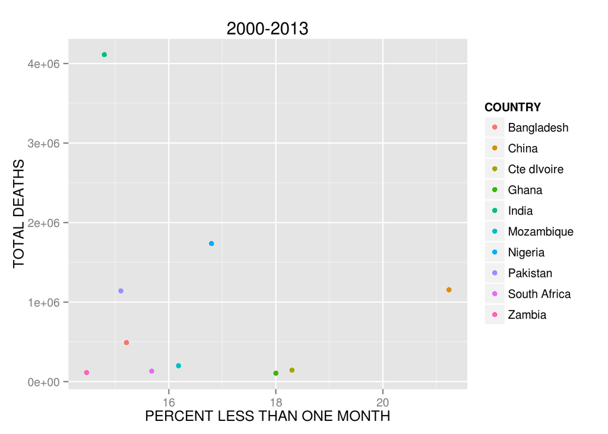

# Plot 3

```r
source("../02 Data Wrangling/Data_Wrangling_P1.R", echo=TRUE)
```

```
##
## > require("jsonlite")
##
## > require("RCurl")
##
## > require("dplyr")
##
## > require("tidyr")
##
## > require("ggplot2")
##
## > require("extrafont")
##
## > df <- data.frame(fromJSON(getURL(URLencode("129.152.144.84:5001/rest/native/?query=\"select * from infected\""),
## +     httpheader = c(DB = "jdbc:or ..." ... [TRUNCATED]
##
## > td2 <- df %>% arrange(desc(DEATHS_0_TO_4_YEARS)) %>%
## +     mutate(total_deaths_percent = cume_dist(DEATHS_0_TO_4_YEARS)) %>%
## +     group_by(YEAR)  .... [TRUNCATED]
##
## > head(td2)
## Source: local data frame [6 x 6]
## Groups: YEAR
##
##   COUNTRY YEAR DEATHS_LESS_THAN_1_MONTH DEATHS_1_TO_59_MONTHS
## 1   India 2000                    64343                376482
## 2   India 2001                    60894                355439
## 3   India 2002                    57566                333685
## 4   India 2003                    54752                310094
## 5   India 2004                    51374                287994
## 6   India 2005                    48192                267185
## Variables not shown: DEATHS_0_TO_4_YEARS (int), total_deaths_percent (dbl)
##
## > ggplot() + coord_cartesian() + scale_x_continuous() +
## +     scale_y_continuous() + labs(title = "DEATHS IN TOP 0.05% COUNTRIES") +
## +     labs(x =  .... [TRUNCATED]
```

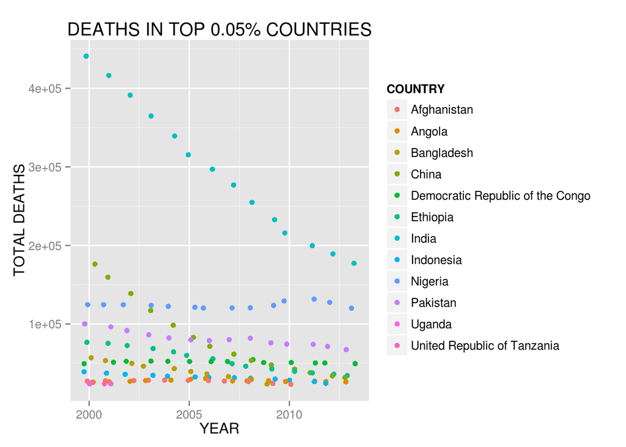

# Summary

```r
source("../01 Data/summary.R", echo=TRUE)
```

```
##
## > df <- data.frame(fromJSON(getURL(URLencode("129.152.144.84:5001/rest/native/?query=\"select * from RESPIRATORY_INFECTIONS\""),
## +     httpheader = c .... [TRUNCATED]
##
## > summary(df)
##                 COUNTRY          YEAR      DEATHS_LESS_THAN_1_MONTH
##  Afghanistan        :  14   Min.   :2000   Min.   :    0.0
##  Albania            :  14   1st Qu.:2003   1st Qu.:    3.0
##  Algeria            :  14   Median :2006   Median :   54.5
##  Andorra            :  14   Mean   :2006   Mean   :  954.9
##  Angola             :  14   3rd Qu.:2010   3rd Qu.:  487.2
##  Antigua and Barbuda:  14   Max.   :2013   Max.   :64343.0
##  (Other)            :2632
##  DEATHS_1_TO_59_MONTHS DEATHS_0_TO_4_YEARS
##  Min.   :     0.0      Min.   :     0
##  1st Qu.:    15.0      1st Qu.:    20
##  Median :   287.5      Median :   345
##  Mean   :  5542.1      Mean   :  6497
##  3rd Qu.:  3211.2      3rd Qu.:  3748
##  Max.   :376482.0      Max.   :440825
##
```

# Subset

```r
source("../01 Data/subset.R", echo=TRUE)
```

[output not shown]

[output cut: 5424 more lines]